# Assignment 2

## Problem 1

The Dataset_I contains information on 7 commonly sold fish species in the market. Using this dataset, it is possible to build a predictive model that utilizes machine-readable data to estimate the weight of fish. Please consider the dataset I and perform the following steps:

$$ Section\ A$$

a) Determine the number of fish species present in the dataset and analyze their distribution across each class. (Plot a bar chart too!)

$$ Importing\ modules $$

```python
import numpy as np
import pandas as pd
from sklearn.linear_model import LinearRegression
from sklearn.model_selection import train_test_split
from sklearn.metrics import mean_squared_error, mean_absolute_error
from sklearn.preprocessing import PolynomialFeatures
from sklearn.pipeline import make_pipeline
from pandas.plotting import scatter_matrix
from matplotlib import pyplot as plt
import seaborn as sns
```

$$ Loading\ the\ dataset$$

```
Number of unique species: 7
```

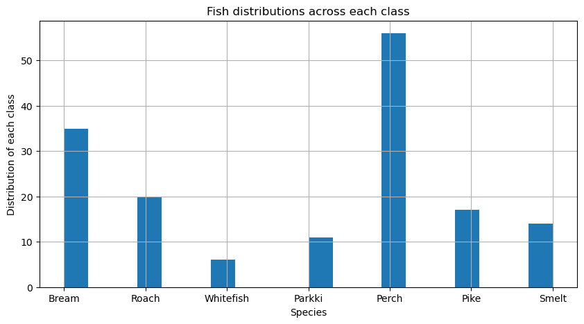

```python
dataset = pd.read_csv('Dataset_I.csv')

fish_spec = dataset['Species'].unique()
print ("Number of unique species: " + str(len(fish_spec)))

dataset['Species'].hist(bins=20, figsize=(10,5))
plt.title('Fish distributions across each class')
plt.xlabel('Species')
plt.ylabel('Distribution of each class')
plt.show()
```

$$ Distribution\ of\ species\ across\ each\ class $$

```
The number of fish in each class:
Perch        56
Bream        35
Roach        20
Pike         17
Smelt        14
Parkki       11
Whitefish     6
Name: Species, dtype: int64
```

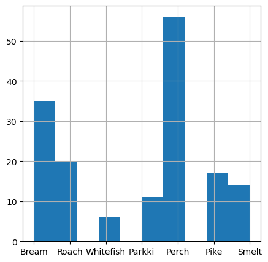

```python
print("The number of fish in each class: " + '\n' + str(dataset['Species'].value_counts()))
dataset['Species'].hist(figsize=(5,5))
plt.show()
```

$$ Section\ B$$

b) Find the relationship between the following features: (weight and width) ,( weight and diagonal length), (cross length and vertical length). Use scatter diagrams to visualize the data and provide a detailed explanation of your findings.

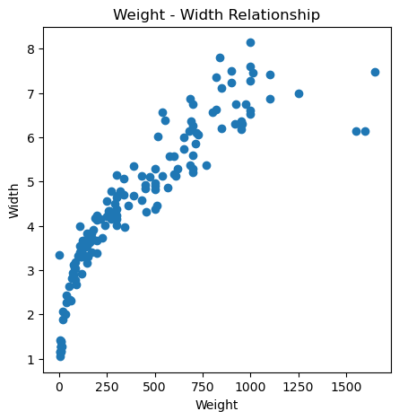

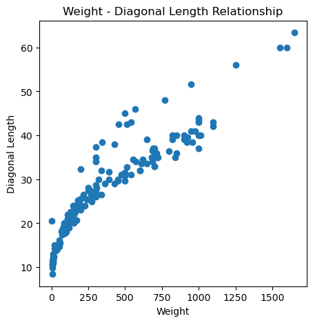

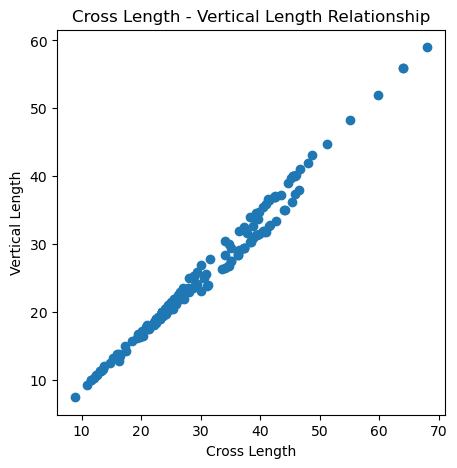

```python
plt.figure(figsize=(5,5))
plt.scatter(dataset['Weight'], dataset['Width'])
plt.title('Weight - Width Relationship')
plt.xlabel('Weight')
plt.ylabel('Width')
plt.show()

plt.figure(figsize=(5,5))
plt.scatter(dataset['Weight'], dataset['Diagonal_Length'])
plt.title('Weight - Diagonal Length Relationship')
plt.xlabel('Weight')
plt.ylabel('Diagonal Length')
plt.show()

plt.figure(figsize=(5,5))
plt.scatter(dataset['Cross_Length'], dataset['Vertical_Length'])
plt.title('Cross Length - Vertical Length Relationship')
plt.xlabel('Cross Length')
plt.ylabel('Vertical Length')
plt.show()
```

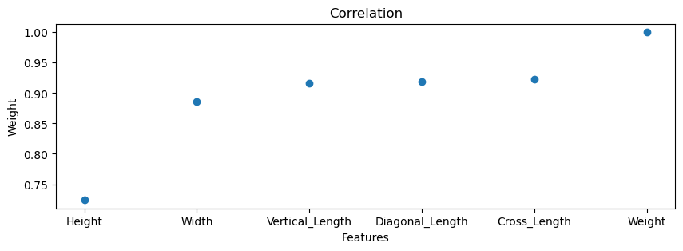

```python
data_corr = dataset.corr(numeric_only=True)
corr = data_corr['Weight'].sort_values(ascending=True)

plt.figure(figsize=(10,3))
plt.scatter(corr.index, corr.values)
plt.title('Correlation')
plt.ylabel('Weight')
plt.xlabel('Features')
plt.show()
```

**There is a strong correlation between "Weight" and "Cross_Length", "Diagonal_Length" and "Vertical_Length".**

$$ Section\ C$$

c) Develop a simple linear regression model for (cross length vs vertical length). Fit the model and assess its performance using the mean squared error (MSE) and mean absolute error (MAE) metrics. Compare and plot the results.

```
Mean Squared Error: 1.8588419652462846
Mean Absolute Error: 1.155728988129315
```

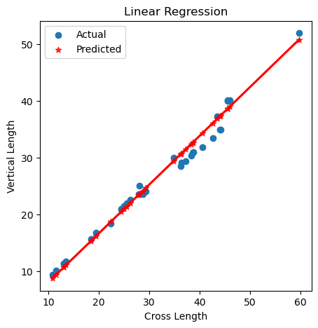

```python
train_data, test_data = train_test_split(dataset, test_size=0.2, random_state=42)

X_train, Y_train = train_data['Cross_Length'], train_data['Vertical_Length']
X_test, Y_test = test_data['Cross_Length'], test_data['Vertical_Length']

model = LinearRegression()
model.fit(X_train.values.reshape(-1,1), Y_train.values.reshape(-1,1))
Y_pred = model.predict(X_test.values.reshape(-1,1))

mse = mean_squared_error(Y_test, Y_pred)
mae = mean_absolute_error(Y_test, Y_pred)

print("Mean Squared Error: " + str(mse))
print("Mean Absolute Error: " + str(mae))

plt.figure(figsize=(5,5))
plt.scatter(X_test, Y_test)
sns.regplot(x=X_test, y=Y_pred, marker='*', color='red')
plt.title('Linear Regression')
plt.xlabel('Cross Length')
plt.ylabel('Vertical Length')
plt.legend(['Actual', 'Predicted'])
plt.show()
```

$$Section\ D$$

d) Identify the features that have the most significant impact on fish weight and choose three of these features for further evaluation. Develop a multiple linear regression model to assess the influence of these features on fish weight and evaluate the model using the MSE and MAE metrics. Plot the results to provide a visual representation of your findings.

```
Mean Squared Error: 22666.611432030142
Mean Absolute Error: 120.36273469493972
```

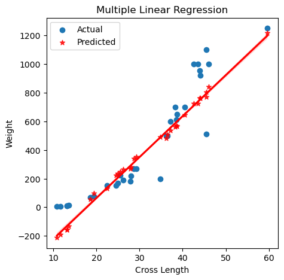

```python
model = LinearRegression()

X_train, Y_train = train_data[['Vertical_Length', 'Diagonal_Length','Cross_Length']].values.reshape(-1,3), train_data['Weight'].values.reshape(-1,1)
X_test, Y_test = test_data[['Vertical_Length', 'Diagonal_Length','Cross_Length']].values.reshape(-1,3), test_data['Weight'].values.reshape(-1,1)

model.fit(X_train, Y_train)
pred = model.predict(X_test).reshape(-1,1)

mse = mean_squared_error(Y_test, pred)
mae = mean_absolute_error(Y_test, pred)

print("Mean Squared Error: " + str(mse))
print("Mean Absolute Error: " + str(mae))

plt.figure(figsize=(5,5))
plt.scatter(X_test[:,2], Y_test)
sns.regplot(x=X_test[:,2], y=pred, marker='*', color='red')
plt.title('Multiple Linear Regression')
plt.xlabel('Cross Length')
plt.ylabel('Weight')
plt.legend(['Actual', 'Predicted'])
plt.show()
```

**According to section B and the illustrated correlation scatter plot, cross lenght, diagonal length and vertical length have the most correlation with weight respectively. So in the current section, these three features have been selected as input features.**

$$\ f_{(x)} = w_{(0)} + w_{(1)}x_{(1)} + w_{(2)}x_{(2)} + w_{(3)}x_{(3)}$$

```python
print("\u03C90", "=" , int(model.intercept_))
print("\u03C91" + " = " + str(int(model.coef_[0,0])) + '\n' +
      "\u03C92" + " = " + str(int(model.coef_[0,1])) + '\n' +
      "\u03C93" + " = " + str(int(model.coef_[0,2])))
```

```
ω0 = -506
ω1 = -61
ω2 = 75
ω3 = 11
```

**The coefficients of the linear regression function are printed out.**

$$Section\ E$$

e) Develop a polynomial regression model for (weight vs width), as well as (weight vs height).

```
Mean Squared Error: 9173.41609712108
Mean Absolute Error: 66.214686644645
```

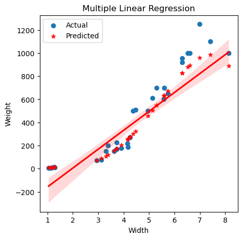

```python
poly_model = PolynomialFeatures(degree=4, include_bias=True)
linear_model = LinearRegression()

X_train, Y_train = train_data['Width'], train_data['Weight']
X_test, Y_test = test_data['Width'], test_data['Weight']

poly_reg = make_pipeline(poly_model, linear_model)
poly_reg.fit(X_train.values.reshape(-1,1), Y_train.values.reshape(-1,1))
Y_pred = poly_reg.predict(X_test.values.reshape(-1,1))

mse = mean_squared_error(Y_test, Y_pred)
mae = mean_absolute_error(Y_test, Y_pred)

print("Mean Squared Error: " + str(mse))
print("Mean Absolute Error: " + str(mae))

plt.figure(figsize=(5,5))
plt.scatter(X_test, Y_test)
sns.regplot(x=X_test, y=Y_pred, marker='*', color='red')
plt.title('Multiple Linear Regression')
plt.xlabel('Width')
plt.ylabel('Weight')
plt.legend(['Actual', 'Predicted'])
plt.show()
```

```
Mean Squared Error: 37599.36518371035
Mean Absolute Error: 127.55838184164722
```

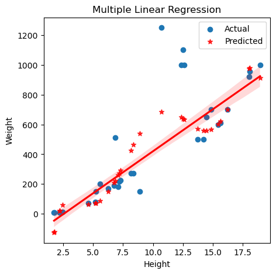

```python
poly_model = PolynomialFeatures(degree=6, include_bias=True)
linear_model = LinearRegression()

X_train, Y_train = train_data['Height'], train_data['Weight']
X_test, Y_test = test_data['Height'], test_data['Weight']

poly_reg = make_pipeline(poly_model, linear_model)
poly_reg.fit(X_train.values.reshape(-1,1), Y_train.values.reshape(-1,1))
Y_pred = poly_reg.predict(X_test.values.reshape(-1,1))

mse = mean_squared_error(Y_test, Y_pred)
mae = mean_absolute_error(Y_test, Y_pred)

print("Mean Squared Error: " + str(mse))
print("Mean Absolute Error: " + str(mae))

plt.figure(figsize=(5,5))
plt.scatter(X_test, Y_test)
sns.regplot(x=X_test, y=Y_pred, marker='*', color='red')
plt.title('Multiple Linear Regression')
plt.xlabel('Height')
plt.ylabel('Weight')
plt.legend(['Actual', 'Predicted'])
plt.show()
```

**Since width-weight correlation is much higher than height-weight, the model trained using the width feature has a significantly lower error in comparison to the model which was trained on height features**